# Presentation

Adela Sobotkova  
24 July

### Who am I?

- Landscape/survey archaeologist (SE Europe, SE Australia)
- eResearch infrastructure domain expert (FAIMS,offline human mediated data collection)
- Software Carpentry instructor
- Digital historian (I am faking this one :)

### What [and how] are we going to learn this week?

- Avoid pitfalls when managing data in spreadsheets
- Make data cleaning a breeze with Open Refine
- Work (run and edit scripts) in R
- Practice basic text mining

The schedule loosely follows the Library Carpentry curriculum. Carpentries teach fundamental computing skills for non-programmeers in a learn-by-doing and learn-by-observation approach.

Hands-on approach includes a reliance on the data-science notion of “hacking” (not “cracking”). Learn best by experimenting and by working on your own project.

### Data in Spreadsheets

Although huge quantities of data today are born digitally, most of us (including programming wizards) still work with data in spreadsheets. Handling and managing spreadsheets is the bread and butter of data work today, so we'll look over and brainstorm some tipcs to avoid unnecessary blunders.

### "For Big-Data Scientists, ‘Janitor Work’ Is Key Hurdle to Insights"

[figure not shown]

It has been written that 80% of any data project is comprised of data cleaning.

see NYT article by Peter DaSilva at http://bit.ly/dirtydatahurdle

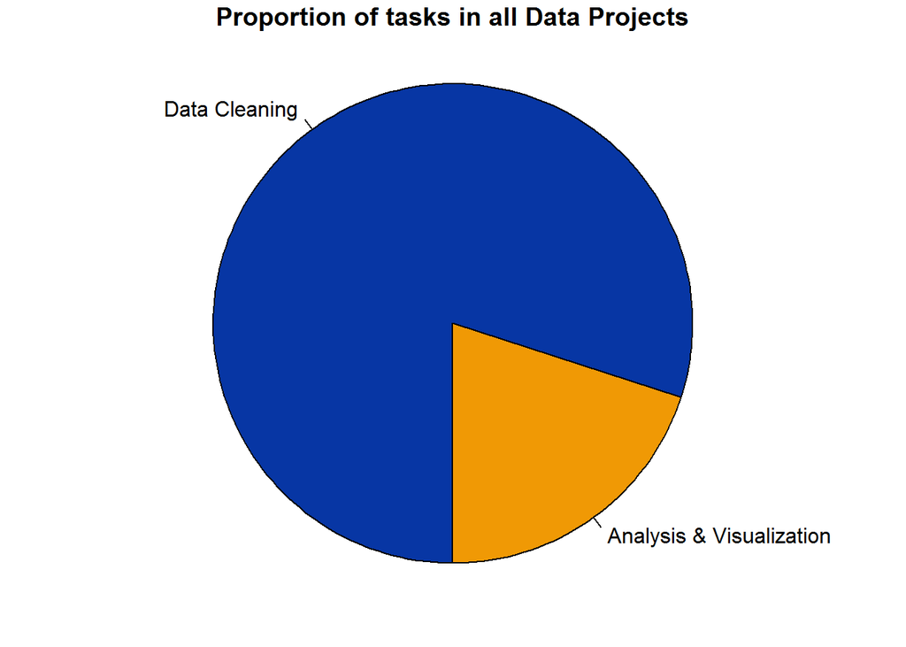

### Data Cleaning - Open Refine

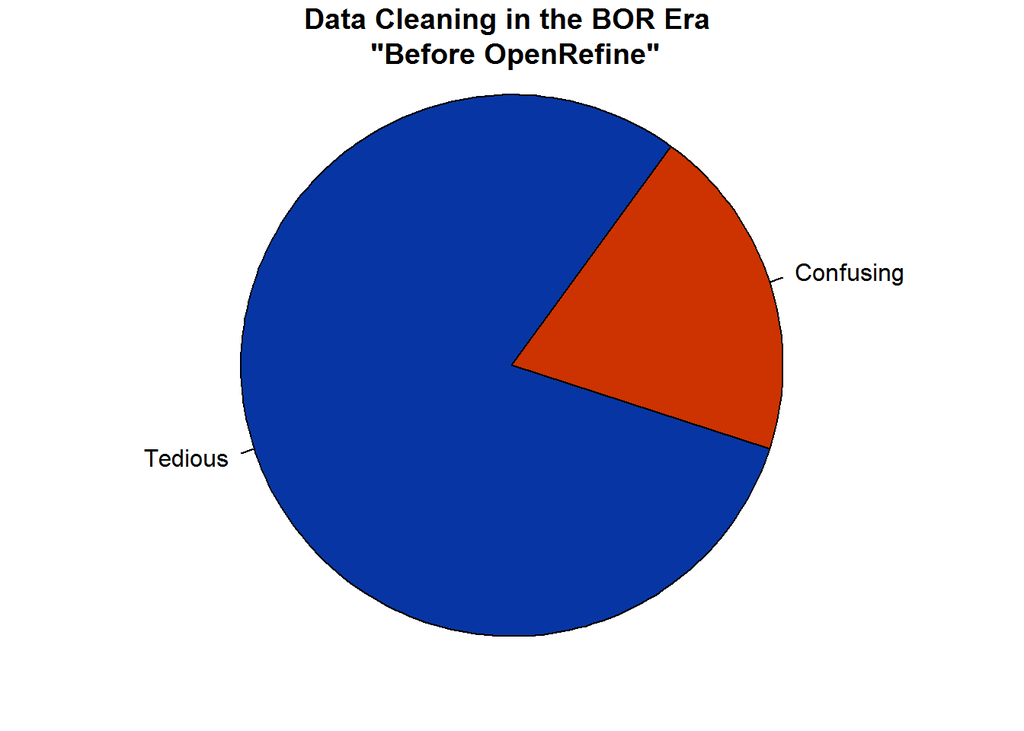

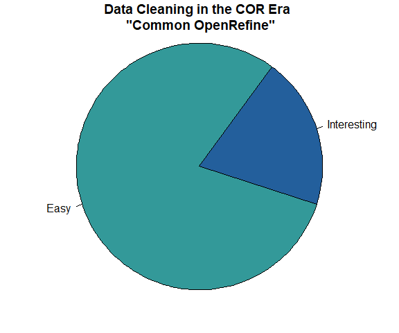

### Data Cleaning - Open Refine

Digital tools

[figure not shown]

```r
summary(cars)
```

```
     speed           dist
 Min.   : 4.0   Min.   :  2.00
 1st Qu.:12.0   1st Qu.: 26.00
 Median :15.0   Median : 36.00
 Mean   :15.4   Mean   : 42.98
 3rd Qu.:19.0   3rd Qu.: 56.00
 Max.   :25.0   Max.   :120.00
```